# housing.Rmd

Downloading the necessary libraries:

```r
library(ggplot2)
library(readr)
library(dplyr)
library(tidyr)
library(Hmisc)
library(ggplot2)
library(ggpubr)
library(cowplot)
library(corrr)
library(leaflet)
library(leaflet.extras)
library(wesanderson)
library(readxl)
```

Reading the housing file into housing dataframe:

```r
housing<-read.csv("kc_house_data.csv")
head(housing)
```

```
##           id            date   price bedrooms bathrooms sqft_living sqft_lot
## 1 7129300520 20141013T000000  221900        3      1.00        1180     5650
## 2 6414100192 20141209T000000  538000        3      2.25        2570     7242
## 3 5631500400 20150225T000000  180000        2      1.00         770    10000
## 4 2487200875 20141209T000000  604000        4      3.00        1960     5000
## 5 1954400510 20150218T000000  510000        3      2.00        1680     8080
## 6 7237550310 20140512T000000 1225000        4      4.50        5420   101930
##   floors waterfront view condition grade sqft_above sqft_basement yr_built
## 1      1          0    0         3     7       1180             0     1955
## 2      2          0    0         3     7       2170           400     1951
## 3      1          0    0         3     6        770             0     1933
## 4      1          0    0         5     7       1050           910     1965
## 5      1          0    0         3     8       1680             0     1987
## 6      1          0    0         3    11       3890          1530     2001
##   yr_renovated zipcode     lat     long sqft_living15 sqft_lot15
## 1            0   98178 47.5112 -122.257          1340       5650
## 2         1991   98125 47.7210 -122.319          1690       7639
## 3            0   98028 47.7379 -122.233          2720       8062
## 4            0   98136 47.5208 -122.393          1360       5000
## 5            0   98074 47.6168 -122.045          1800       7503
## 6            0   98053 47.6561 -122.005          4760     101930
```

```r
summary(housing)
```

```
##        id                date               price            bedrooms
##  Min.   :1.000e+06   Length:21613       Min.   :  75000   Min.   : 0.000
##  1st Qu.:2.123e+09   Class :character   1st Qu.: 321950   1st Qu.: 3.000
##  Median :3.905e+09   Mode  :character   Median : 450000   Median : 3.000
##  Mean   :4.580e+09                      Mean   : 540088   Mean   : 3.371
##  3rd Qu.:7.309e+09                      3rd Qu.: 645000   3rd Qu.: 4.000
##  Max.   :9.900e+09                      Max.   :7700000   Max.   :33.000
##    bathrooms      sqft_living       sqft_lot           floors
##  Min.   :0.000   Min.   :  290   Min.   :    520   Min.   :1.000
##  1st Qu.:1.750   1st Qu.: 1427   1st Qu.:   5040   1st Qu.:1.000
##  Median :2.250   Median : 1910   Median :   7618   Median :1.500
##  Mean   :2.115   Mean   : 2080   Mean   :  15107   Mean   :1.494
##  3rd Qu.:2.500   3rd Qu.: 2550   3rd Qu.:  10688   3rd Qu.:2.000
##  Max.   :8.000   Max.   :13540   Max.   :1651359   Max.   :3.500
##    waterfront            view          condition         grade
##  Min.   :0.000000   Min.   :0.0000   Min.   :1.000   Min.   : 1.000
##  1st Qu.:0.000000   1st Qu.:0.0000   1st Qu.:3.000   1st Qu.: 7.000
##  Median :0.000000   Median :0.0000   Median :3.000   Median : 7.000
##  Mean   :0.007542   Mean   :0.2343   Mean   :3.409   Mean   : 7.657
##  3rd Qu.:0.000000   3rd Qu.:0.0000   3rd Qu.:4.000   3rd Qu.: 8.000
##  Max.   :1.000000   Max.   :4.0000   Max.   :5.000   Max.   :13.000
##    sqft_above   sqft_basement       yr_built     yr_renovated
##  Min.   : 290   Min.   :   0.0   Min.   :1900   Min.   :   0.0
##  1st Qu.:1190   1st Qu.:   0.0   1st Qu.:1951   1st Qu.:   0.0
##  Median :1560   Median :   0.0   Median :1975   Median :   0.0
##  Mean   :1788   Mean   : 291.5   Mean   :1971   Mean   :  84.4
##  3rd Qu.:2210   3rd Qu.: 560.0   3rd Qu.:1997   3rd Qu.:   0.0
##  Max.   :9410   Max.   :4820.0   Max.   :2015   Max.   :2015.0
##     zipcode           lat             long        sqft_living15
##  Min.   :98001   Min.   :47.16   Min.   :-122.5   Min.   : 399
##  1st Qu.:98033   1st Qu.:47.47   1st Qu.:-122.3   1st Qu.:1490
##  Median :98065   Median :47.57   Median :-122.2   Median :1840
##  Mean   :98078   Mean   :47.56   Mean   :-122.2   Mean   :1987
##  3rd Qu.:98118   3rd Qu.:47.68   3rd Qu.:-122.1   3rd Qu.:2360
##  Max.   :98199   Max.   :47.78   Max.   :-121.3   Max.   :6210
##    sqft_lot15
##  Min.   :   651
##  1st Qu.:  5100
##  Median :  7620
##  Mean   : 12768
##  3rd Qu.: 10083
##  Max.   :871200
```

Setting up a map to check price and longitude and latitude:

```r
leaflet_map<-leaflet(options = leafletOptions(minZoom = 0, maxZoom = 20))%>%
  addTiles()%>%
  setView(lng=-122.257,lat=47.5112, zoom=12)
leaflet_map
```

[interactive chart not shown]

```r
seattle<-housing[,c("long","lat")]

leaflet_map<-leaflet(data=seattle, options = leafletOptions(minZoom = 0,maxZoom = 18))%>%
  addTiles()%>% setView(lng=-122.5, lat=47.6, zoom = 11)%>%
  addCircleMarkers(lng=~long,lat=~lat, radius = 5, color = 'grey', stroke = FALSE, fillOpacity = 0.6)

leaflet_map
```

[interactive chart not shown]

Adding heatmap with price intensity:

```r
max<- max(housing$price)

leaflet_map2<-leaflet(data=housing, options = leafletOptions(minZoom = 0,maxZoom = 18))%>%
  addTiles()%>% setView(lng=-122.25, lat=47.6, zoom = 11)%>%
  addHeatmap(lng=~long,lat=~lat, intensity = ~price, minOpacity = 0.2, max=max, radius = 6, blur = 7)

leaflet_map2
```

[interactive chart not shown]

Looking at the correlation between longitude and price of houses:

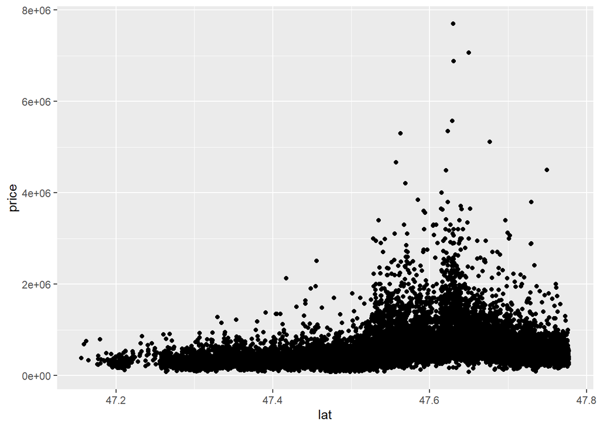

```r
ggplot(housing, aes(lat,price))+geom_point()
```

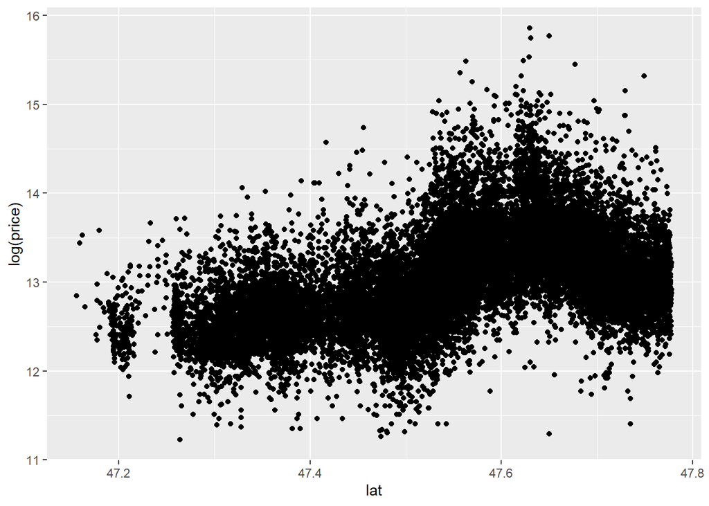

```r
ggplot(housing, aes(lat,log(price)))+geom_point()
```

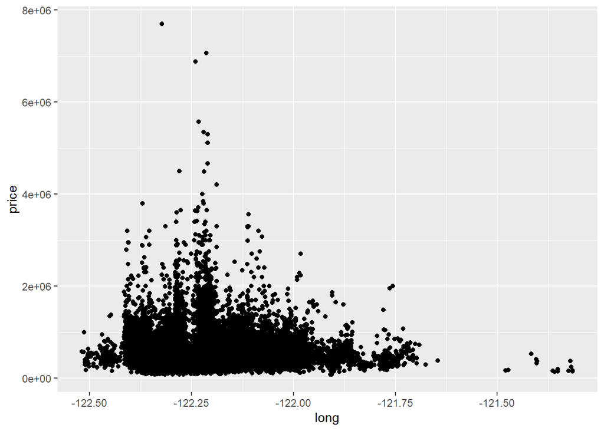

```r
ggplot(housing, aes(long,price))+geom_point()
```

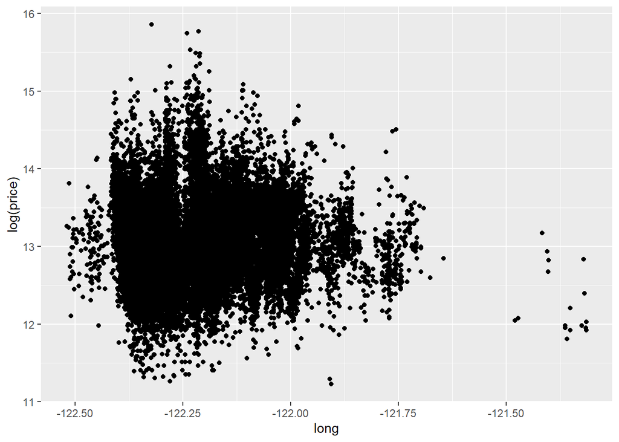

```r
ggplot(housing, aes(long,log(price)))+geom_point()
```

```r
housing2<-housing%>%filter(long > (-122.25) & long < (-122.20))%>%filter(lat > 47.5 & lat < 47.60)

leaflet_map3<-leaflet(data=housing2, options = leafletOptions(minZoom = 0, maxZoom = 20))%>%
  addTiles()%>%
  setView(lng=-122.25,lat=47.5, zoom=11)%>%
  addCircleMarkers(lng = ~long,lat = ~lat, radius = 4, fillOpacity = TRUE)
leaflet_map3
```

[interactive chart not shown]

This makes sense from my own knowledge of the city with higher prices in Mercer Island and around Lake Washington. It also seems like prices are higher around the water. More on that soon.

Now, I want to check the prices per neighborhood in the city. I suspect there will be differences in distribution of prices in some neighborhoods.I will now checking the unique zip codes in the dataset and transferring them into neighborhoods by using an excel file with neighborhood names:

```r
zipcodelist<-unique(housing$zipcode)
zipcodelist<-sort(zipcodelist)

#converting to dataframe so I can export to excel and add the neighborhood names so I can cbind it to the original dataframe.
zipcodelist<-as.data.frame(zipcodelist)
zipneighborhood<-read_excel("zipcode.xlsx")
zipneighborhood<-as.data.frame(zipneighborhood)
head(zipneighborhood,5)
```

```
##   zipcodelist neighbourhood
## 1       98001        Auburn
## 2       98002        Auburn
## 3       98003   Federal Way
## 4       98004      Bellevue
## 5       98005      Bellevue
```

```r
colnames(zipneighborhood)<-c("zipcode","neighborhood")

#joining both datasets:
housing_w_neigh<-full_join(housing,zipneighborhood, by="zipcode")
```

Next I use a boxplot to see the price distribution for all neighborhoods in the dataset:

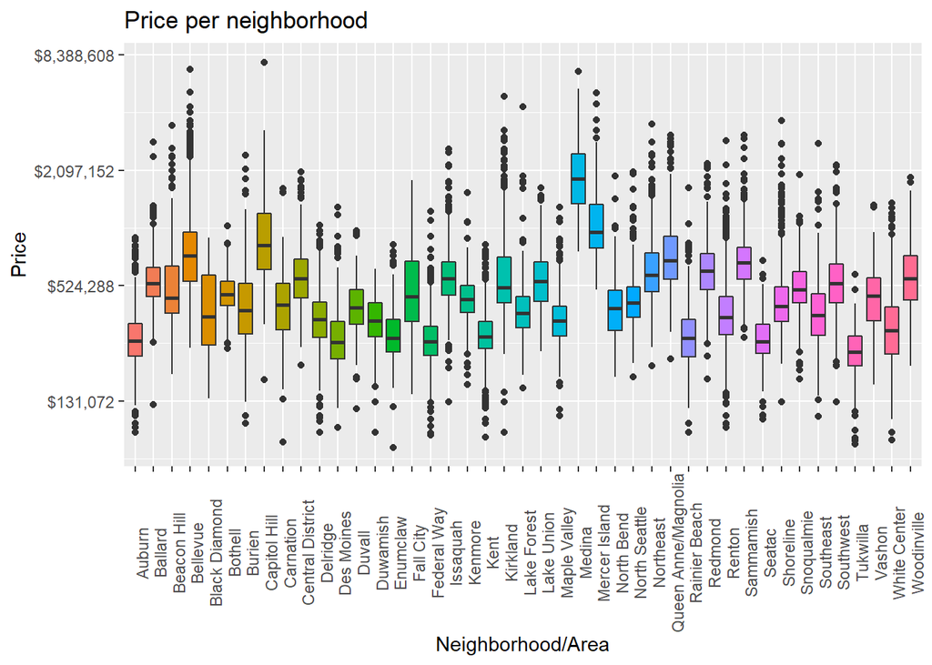

```r
price_neighborhood<-ggplot(housing_w_neigh,aes(factor(neighborhood),price))+geom_boxplot(aes(fill=neighborhood))+
  scale_y_continuous(trans = "log2", labels = scales::dollar_format())+labs(title = "Price per neighborhood", y="Price", x= "Neighborhood/Area")+theme(legend.position = "none", axis.text.x = element_text(angle = 90) )
#to save graph in case needed:
#ggsave("priceneighborhood.png",price_neighborhood)
price_neighborhood
```

It looks like there is a difference between price ranges in different neighborhoods in Seattle with the highest ones being Capitol Hill, Medina, and Mercer Island. Now, let’s look at prices houses with a waterfront and those with no waterfront. Analyzing all houses in the region, we do see a significant differece in price for those who are by the water and those that are not:

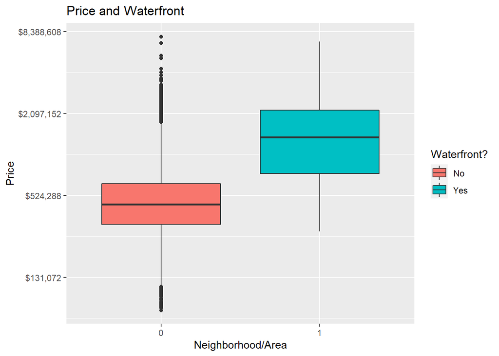

```r
pricewaterfront<-ggplot(housing_w_neigh,aes(as.factor(waterfront),price, fill=as.factor(waterfront)))+geom_boxplot()+
  scale_y_continuous(trans = "log2", labels = scales::dollar_format())+scale_fill_discrete(labels=c("No","Yes"))+
labs(title = "Price and Waterfront", y="Price", x= "Neighborhood/Area", fill="Waterfront?")
#ggsave("pricewaterfront.png",pricewaterfront)
pricewaterfront
```

Now, it will be helpful to look at different neighborhoods and see if the pattern repeats across neighborhoods that have waterfront houses.It looks like the pattern repeats itself in neighborhoods as well:

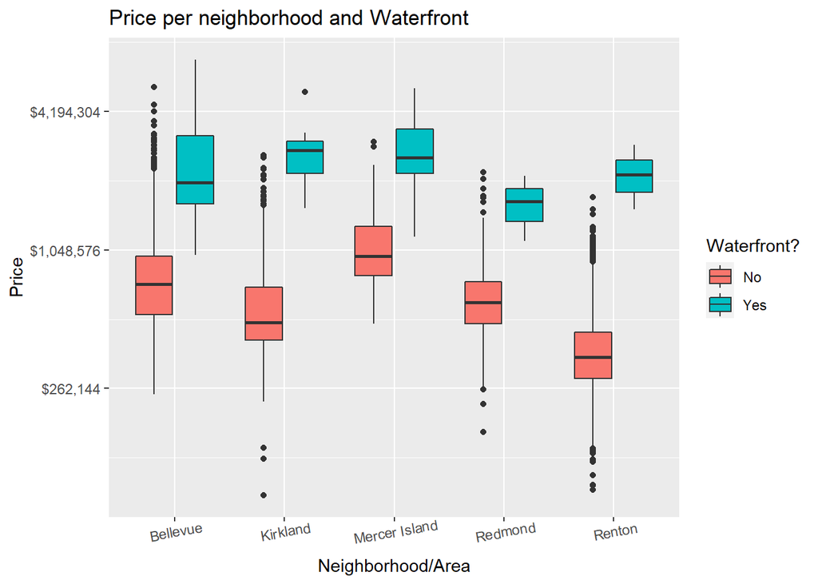

```r
price_per_neighborhood_waterfront<-housing_w_neigh%>%filter(neighborhood %in% c("Mercer Island","Kirkland", "Renton","Redmond", "Bellevue"))%>%
  ggplot(aes(neighborhood,price,fill=factor(waterfront)))+geom_boxplot()+scale_y_continuous(trans = "log2", labels = scales::dollar_format())+
  scale_fill_discrete(labels=c("No","Yes"))+
labs(title = "Price per neighborhood and Waterfront", y="Price", x= "Neighborhood/Area", fill="Waterfront?")+theme(axis.text.x = element_text(angle = 10))
price_per_neighborhood_waterfront
```

```r
#ggsave("priceneighborhoodwaterfront.png",price_per_neighborhood_waterfront)
```

Now, let’s looking at the distribution of prices for waterfront and no waterfront houses:

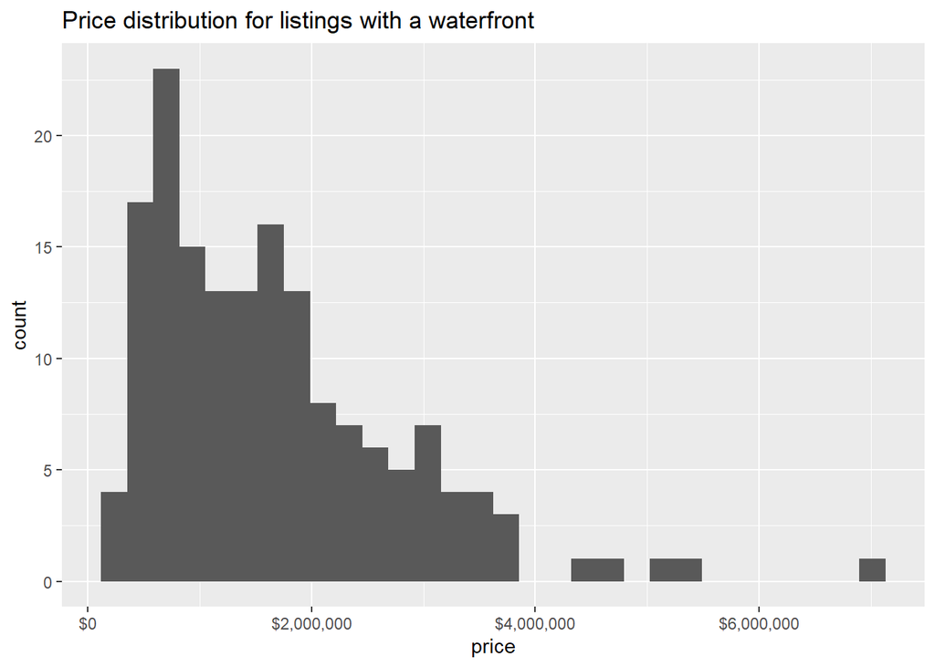

```r
distribution_waterfront<-housing_w_neigh%>%filter(waterfront==1)%>%ggplot(aes(price))+geom_histogram()+scale_x_continuous(labels = scales::dollar_format())+labs(title = "Price distribution for listings with a waterfront")
distribution_waterfront
```

```r
#ggsave("histogramwaterfront.png",distribution_waterfront)
```

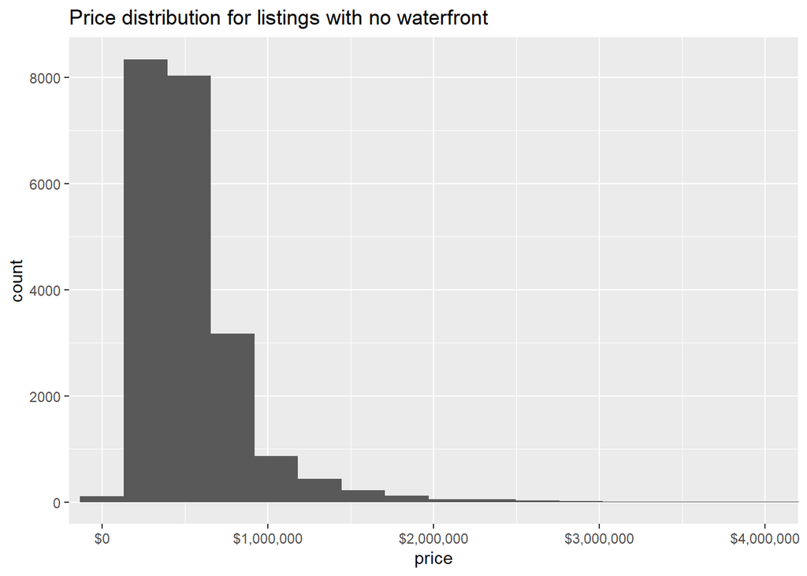

```r
distribution_nowaterfront<-housing_w_neigh%>%filter(waterfront==0)%>%ggplot(aes(price))+geom_histogram()+scale_x_continuous(labels= scales::dollar_format())+coord_cartesian(xlim = c(0,4000000))+labs(title = "Price distribution for listings with no waterfront")
distribution_nowaterfront
```

```r
#ggsave("histogramNOwaterfront.png",distribution_nowaterfront)
```

For the houses with no waterfront, prices are more concentrated around the $500,000 mark. Though again, the tail does suggest some houses in the higher end of prices, reaching $3M.

Now, let’s explore other variables in the dataset. Following it is the plots for the relationship between square feet and price, condition and price, and number of bedrooms and price:

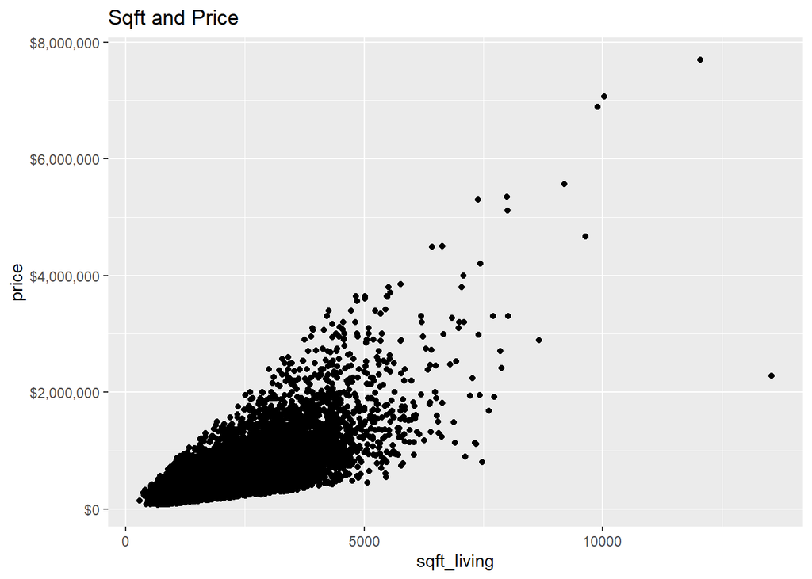

```r
ggplot(housing_w_neigh,aes(sqft_living, price))+geom_point()+labs(title="Sqft and Price")+scale_y_continuous(labels= scales::dollar_format())
```

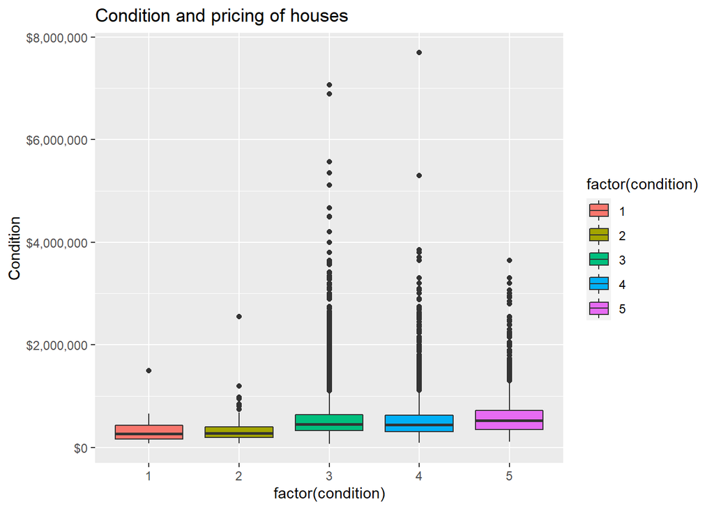

```r
ggplot(housing_w_neigh,aes(factor(condition), price,fill=factor(condition)))+geom_boxplot()+labs(title="Condition and pricing of houses", y="Condition")+scale_y_continuous(labels= scales::dollar_format())
```

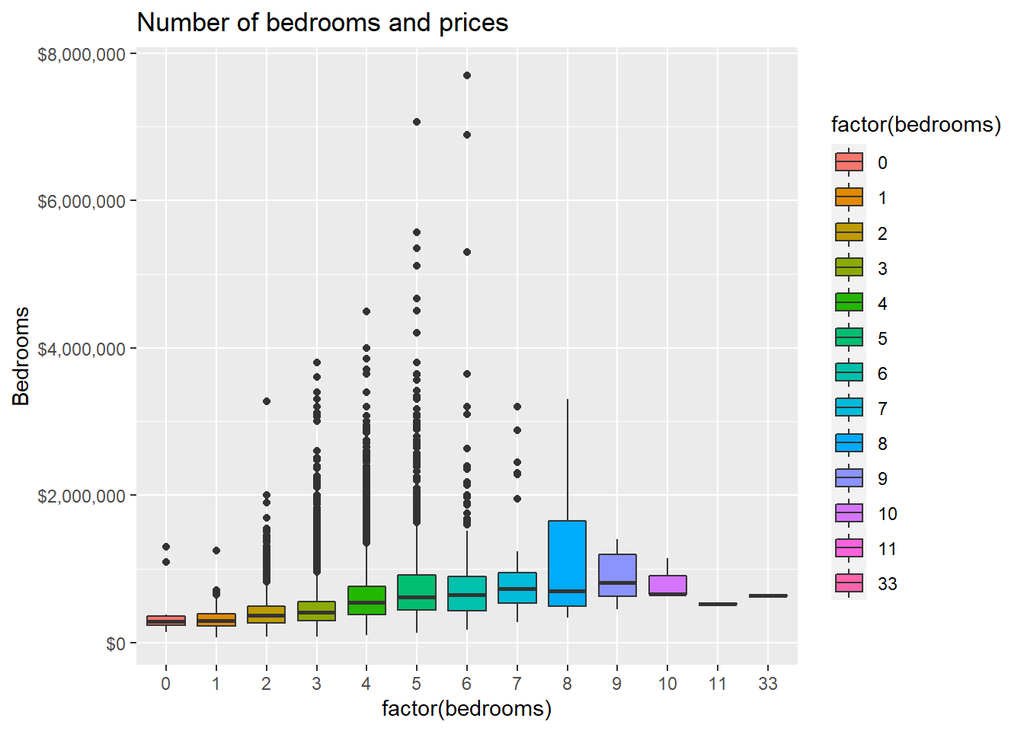

```r
ggplot(housing_w_neigh, aes(factor(bedrooms), price, fill=factor(bedrooms)))+geom_boxplot()+labs(title="Number of bedrooms and prices", y="Bedrooms")+scale_y_continuous(labels = scales::dollar_format())
```

The plot of prices seems to “funnel out” as the square feet increases. It seems that we can benefit from a log transformation in this case to better understand this relationship:

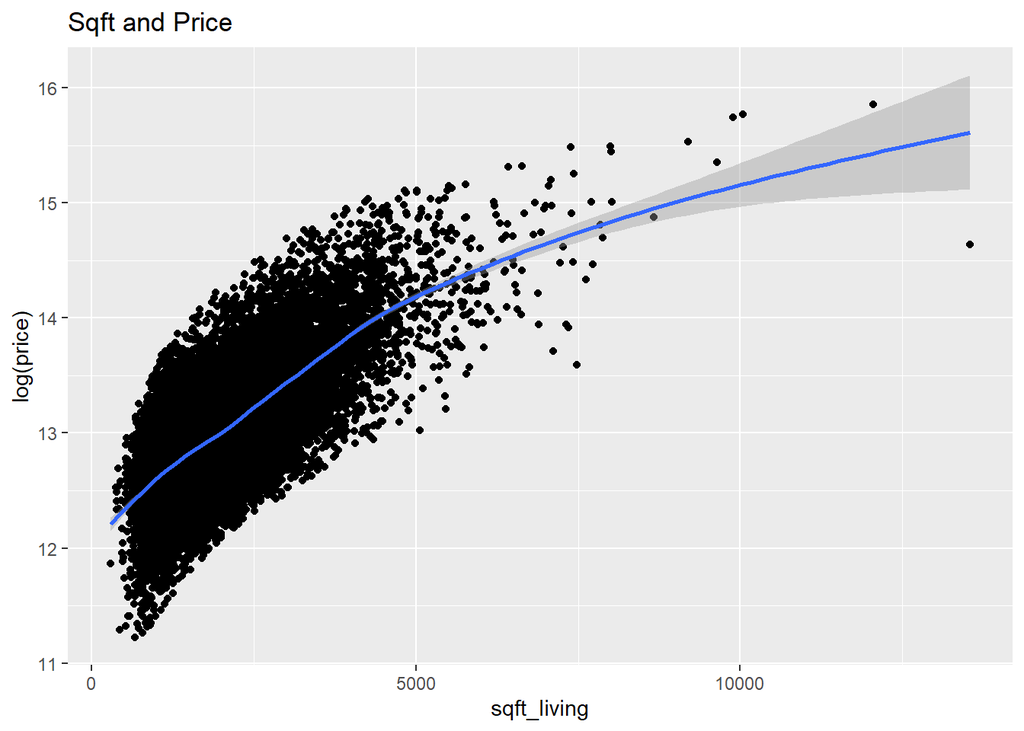

```r
ggplot(housing_w_neigh,aes(sqft_living, log(price)))+geom_point()+labs(title="Sqft and Price")+geom_smooth(aes(sqft_living,log(price)))
```

It looks like prices increase as you add sqft_living until a point around 5000 sqft. Then it “flattens out”.

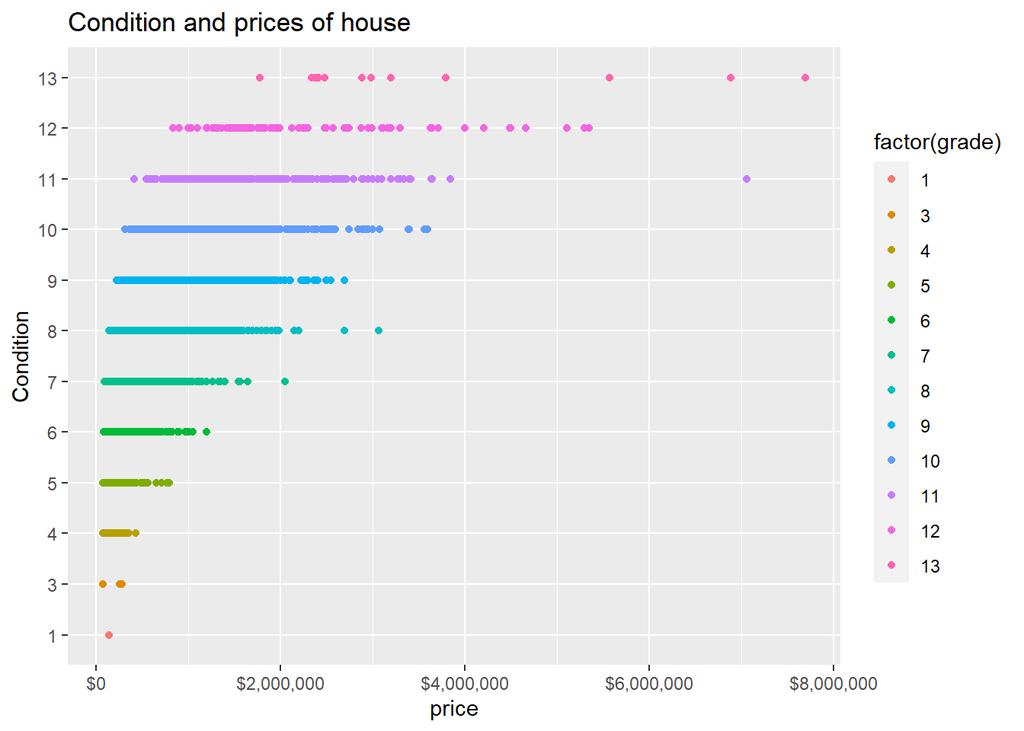

```r
ggplot(housing_w_neigh, aes(price, factor(grade), color = factor(grade)))+geom_point()+scale_x_continuous(labels = scales::dollar_format())+labs(title = "Condition and prices of house", y = "Condition")
```

Lastly, to conclude some explanatory graphics, let’s check the relationship between bedrooms and bathrooms and how they might impact the prices of houses.

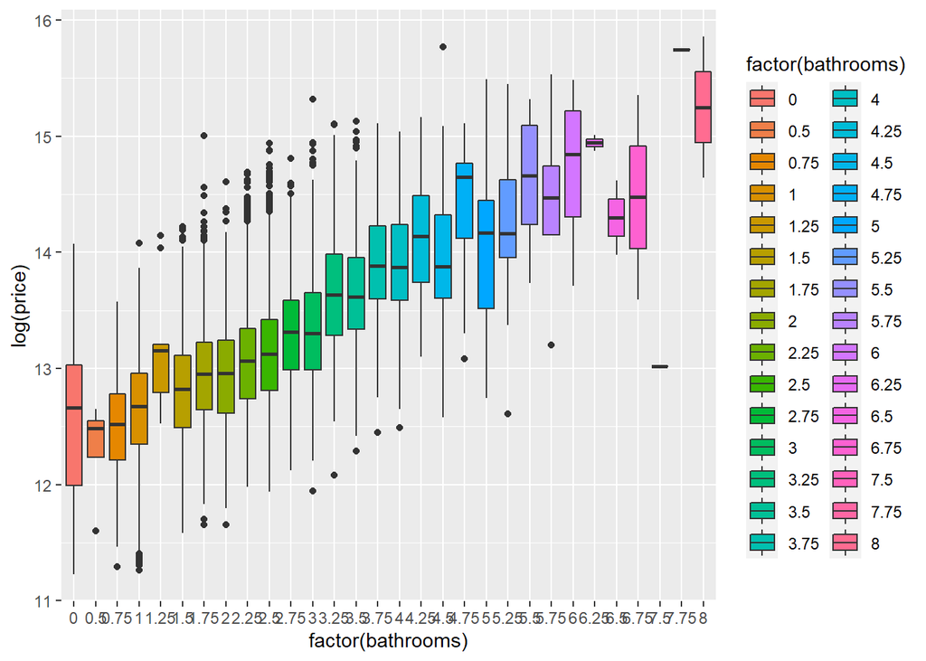

```r
ggplot(housing_w_neigh,aes(factor(bathrooms),log(price), fill=factor(bathrooms)))+geom_boxplot()
```

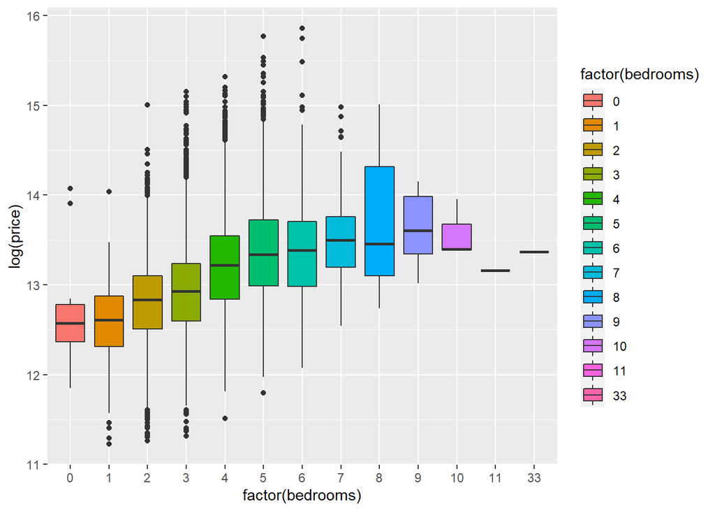

```r
ggplot(housing_w_neigh,aes(factor(bedrooms),log(price), fill=factor(bedrooms)))+geom_boxplot()
```

Now, let’s start checking linear relationships on the data. First the plot I ran earlier with price and sqft living:

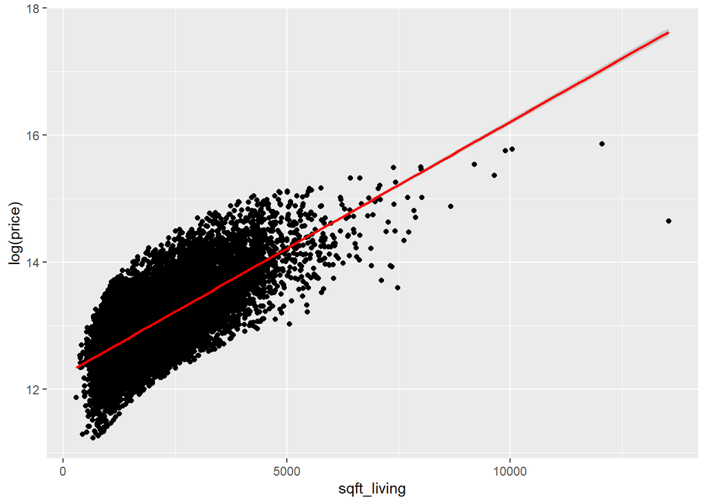

```r
ggplot(housing_w_neigh, aes(sqft_living, log(price)))+geom_point()+geom_smooth(aes(sqft_living,log(price)), color="red", method = "lm")
```

Now let’s run a linear regression in these two variables to better understand the correlation:

```r
price_Sqft<-lm(log(price)~sqft_living,housing_w_neigh)
summary(price_Sqft)
```

```
##
## Call:
## lm(formula = log(price) ~ sqft_living, data = housing_w_neigh)
##
## Residuals:
##      Min       1Q   Median       3Q      Max
## -2.97781 -0.28543  0.01472  0.26070  1.27628
##
## Coefficients:
##              Estimate Std. Error t value Pr(>|t|)
## (Intercept) 1.222e+01  6.374e-03  1916.9   <2e-16 ***
## sqft_living 3.987e-04  2.803e-06   142.2   <2e-16 ***
## ---
## Signif. codes:  0 '***' 0.001 '**' 0.01 '*' 0.05 '.' 0.1 ' ' 1
##
## Residual standard error: 0.3785 on 21611 degrees of freedom
## Multiple R-squared:  0.4835, Adjusted R-squared:  0.4835
## F-statistic: 2.023e+04 on 1 and 21611 DF,  p-value: < 2.2e-16
```

To improve the model, I will add some of the variables I looked at earlier and saw a correlation with price.

```r
first_model<-lm(log(price) ~ bedrooms  + bathrooms + sqft_living + waterfront + condition, data=housing_w_neigh)
summary(first_model)
```

```
##
## Call:
## lm(formula = log(price) ~ bedrooms + bathrooms + sqft_living +
##     waterfront + condition, data = housing_w_neigh)
##
## Residuals:
##      Min       1Q   Median       3Q      Max
## -2.98830 -0.27592  0.01578  0.25240  2.03780
##
## Coefficients:
##               Estimate Std. Error t value Pr(>|t|)
## (Intercept)  1.203e+01  1.677e-02  717.40   <2e-16 ***
## bedrooms    -5.499e-02  3.369e-03  -16.32   <2e-16 ***
## bathrooms    6.793e-02  5.074e-03   13.39   <2e-16 ***
## sqft_living  3.853e-04  4.445e-06   86.67   <2e-16 ***
## waterfront   5.864e-01  2.929e-02   20.02   <2e-16 ***
## condition    7.495e-02  3.915e-03   19.15   <2e-16 ***
## ---
## Signif. codes:  0 '***' 0.001 '**' 0.01 '*' 0.05 '.' 0.1 ' ' 1
##
## Residual standard error: 0.3691 on 21607 degrees of freedom
## Multiple R-squared:  0.509,  Adjusted R-squared:  0.5089
## F-statistic:  4479 on 5 and 21607 DF,  p-value: < 2.2e-16
```

The model still hasn’t improved much. First, I will try to check interactions between the variables to see if we can find some other predictive power within the variables. There might be some interaction happening between the size of the house, its condition, how many bedrooms it has and if it is with a waterfront. The model below (second_model) will check for these interactions:

```r
second_model<-lm(log(price) ~ bedrooms  + bathrooms + sqft_living + waterfront + condition + condition*waterfront +sqft_living*waterfront+sqft_living*condition + sqft_living*bedrooms, data=housing_w_neigh)
summary(second_model)
```

```
##
## Call:
## lm(formula = log(price) ~ bedrooms + bathrooms + sqft_living +
##     waterfront + condition + condition * waterfront + sqft_living *
##     waterfront + sqft_living * condition + sqft_living * bedrooms,
##     data = housing_w_neigh)
##
## Residuals:
##      Min       1Q   Median       3Q      Max
## -2.18154 -0.27712  0.01624  0.25210  1.88297
##
## Coefficients:
##                          Estimate Std. Error t value Pr(>|t|)
## (Intercept)             1.219e+01  3.781e-02 322.351  < 2e-16 ***
## bedrooms               -1.973e-02  5.952e-03  -3.315 0.000917 ***
## bathrooms               6.600e-02  5.065e-03  13.030  < 2e-16 ***
## sqft_living             3.138e-04  1.793e-05  17.501  < 2e-16 ***
## waterfront              1.008e+00  1.624e-01   6.209 5.43e-10 ***
## condition              -1.050e-02  9.598e-03  -1.094 0.273943
## waterfront:condition   -7.819e-02  3.989e-02  -1.960 0.049978 *
## sqft_living:waterfront -4.823e-05  1.844e-05  -2.616 0.008911 **
## sqft_living:condition   4.292e-05  4.415e-06   9.722  < 2e-16 ***
## bedrooms:sqft_living   -1.811e-05  2.438e-06  -7.427 1.15e-13 ***
## ---
## Signif. codes:  0 '***' 0.001 '**' 0.01 '*' 0.05 '.' 0.1 ' ' 1
##
## Residual standard error: 0.3678 on 21603 degrees of freedom
## Multiple R-squared:  0.5125, Adjusted R-squared:  0.5123
## F-statistic:  2524 on 9 and 21603 DF,  p-value: < 2.2e-16
```

There seems to be a correlation between the size of the house and whether it is by the waterfront, the size and its condition, and number of bedrooms and its size. I will come back to the interpretation soon because there are still the neighborhoods that need to be added to the model. The next model will include the significant interactions discussed above with the added neighborhoods:

```r
third_model<-lm(log(price) ~ bedrooms  + bathrooms + sqft_living + waterfront + condition + sqft_living*waterfront + sqft_living*condition + sqft_living*bedrooms + neighborhood, data=housing_w_neigh)
summary(third_model)
```

```
##
## Call:
## lm(formula = log(price) ~ bedrooms + bathrooms + sqft_living +
##     waterfront + condition + sqft_living * waterfront + sqft_living *
##     condition + sqft_living * bedrooms + neighborhood, data = housing_w_neigh)
##
## Residuals:
##     Min      1Q  Median      3Q     Max
## -1.2745 -0.1241 -0.0003  0.1193  1.1298
##
## Coefficients:
##                                   Estimate Std. Error t value Pr(>|t|)
## (Intercept)                      1.131e+01  2.452e-02 461.305  < 2e-16 ***
## bedrooms                         5.935e-02  3.613e-03  16.425  < 2e-16 ***
## bathrooms                        4.418e-02  3.076e-03  14.361  < 2e-16 ***
## sqft_living                      5.465e-04  1.098e-05  49.779  < 2e-16 ***
## waterfront                       8.342e-01  3.948e-02  21.132  < 2e-16 ***
## condition                        7.035e-02  5.801e-03  12.128  < 2e-16 ***
## neighborhoodBallard              8.099e-01  1.062e-02  76.266  < 2e-16 ***
## neighborhoodBeacon Hill          6.572e-01  1.394e-02  47.132  < 2e-16 ***
## neighborhoodBellevue             8.109e-01  9.443e-03  85.874  < 2e-16 ***
## neighborhoodBlack Diamond        2.609e-01  2.314e-02  11.273  < 2e-16 ***
## neighborhoodBothell              4.490e-01  1.734e-02  25.896  < 2e-16 ***
## neighborhoodBurien               3.156e-01  1.564e-02  20.182  < 2e-16 ***
## neighborhoodCapitol Hill         1.051e+00  1.358e-02  77.343  < 2e-16 ***
## neighborhoodCarnation            3.228e-01  2.105e-02  15.332  < 2e-16 ***
## neighborhoodCentral District     8.315e-01  1.484e-02  56.024  < 2e-16 ***
## neighborhoodDelridge             4.175e-01  1.115e-02  37.440  < 2e-16 ***
## neighborhoodDes Moines           6.701e-02  1.503e-02   4.457 8.34e-06 ***
## neighborhoodDuvall               3.191e-01  1.754e-02  18.196  < 2e-16 ***
## neighborhoodDuwamish             3.102e-01  1.768e-02  17.542  < 2e-16 ***
## neighborhoodEnumclaw             1.058e-01  1.612e-02   6.566 5.29e-11 ***
## neighborhoodFall City            4.679e-01  2.548e-02  18.360  < 2e-16 ***
## neighborhoodFederal Way         -9.256e-03  1.071e-02  -0.864   0.3877
## neighborhoodIssaquah             5.722e-01  1.095e-02  52.250  < 2e-16 ***
## neighborhoodKenmore              4.185e-01  1.495e-02  27.994  < 2e-16 ***
## neighborhoodKent                 4.441e-02  9.643e-03   4.605 4.15e-06 ***
## neighborhoodKirkland             6.559e-01  1.012e-02  64.816  < 2e-16 ***
## neighborhoodLake Forest          4.200e-01  1.271e-02  33.047  < 2e-16 ***
## neighborhoodLake Union           8.126e-01  1.158e-02  70.195  < 2e-16 ***
```

[output cut: 14 more lines]

```
## neighborhoodSoutheast            4.332e-01  1.220e-02  35.505  < 2e-16 ***
## neighborhoodSouthwest            7.429e-01  1.162e-02  63.916  < 2e-16 ***
## neighborhoodTukwilla             3.006e-02  1.532e-02   1.962   0.0498 *
## neighborhoodVashon               3.614e-01  2.206e-02  16.381  < 2e-16 ***
## neighborhoodWhite Center         2.568e-01  1.490e-02  17.231  < 2e-16 ***
## neighborhoodWoodinville          5.224e-01  1.253e-02  41.701  < 2e-16 ***
## sqft_living:waterfront          -6.043e-05  1.106e-05  -5.466 4.65e-08 ***
## sqft_living:condition           -1.524e-05  2.672e-06  -5.703 1.20e-08 ***
## bedrooms:sqft_living            -4.145e-05  1.477e-06 -28.064  < 2e-16 ***
## ---
## Signif. codes:  0 '***' 0.001 '**' 0.01 '*' 0.05 '.' 0.1 ' ' 1
##
## Residual standard error: 0.2196 on 21562 degrees of freedom
## Multiple R-squared:  0.8266, Adjusted R-squared:  0.8262
## F-statistic:  2056 on 50 and 21562 DF,  p-value: < 2.2e-16
```

Now, I am interested in learning about an additional interaction: neighborhoods and whether the house is in a waterfront or not. I will run the fourth model to check these below:

```r
fourth_model<-lm(formula = log(price) ~ bedrooms + bathrooms + sqft_living +
    waterfront + condition + sqft_living * waterfront + sqft_living *
    condition + sqft_living * bedrooms + neighborhood +neighborhood*waterfront, data = housing_w_neigh)
summary(fourth_model)
```

```
##
## Call:
## lm(formula = log(price) ~ bedrooms + bathrooms + sqft_living +
##     waterfront + condition + sqft_living * waterfront + sqft_living *
##     condition + sqft_living * bedrooms + neighborhood + neighborhood *
##     waterfront, data = housing_w_neigh)
##
## Residuals:
##      Min       1Q   Median       3Q      Max
## -1.27740 -0.12374 -0.00042  0.11874  1.12951
##
## Coefficients: (20 not defined because of singularities)
##                                              Estimate Std. Error t value
## (Intercept)                                 1.131e+01  2.447e-02 462.223
## bedrooms                                    5.852e-02  3.604e-03  16.236
## bathrooms                                   4.384e-02  3.067e-03  14.294
## sqft_living                                 5.466e-04  1.097e-05  49.837
## waterfront                                  1.086e+00  8.459e-02  12.844
## condition                                   7.138e-02  5.792e-03  12.324
## neighborhoodBallard                         8.097e-01  1.058e-02  76.517
## neighborhoodBeacon Hill                     6.556e-01  1.392e-02  47.081
## neighborhoodBellevue                        8.120e-01  9.427e-03  86.135
## neighborhoodBlack Diamond                   2.607e-01  2.306e-02  11.305
## neighborhoodBothell                         4.491e-01  1.728e-02  25.996
## neighborhoodBurien                          3.192e-01  1.593e-02  20.041
## neighborhoodCapitol Hill                    1.051e+00  1.354e-02  77.613
## neighborhoodCarnation                       3.227e-01  2.098e-02  15.385
## neighborhoodCentral District                8.315e-01  1.479e-02  56.224
## neighborhoodDelridge                        4.173e-01  1.111e-02  37.556
## neighborhoodDes Moines                      6.825e-02  1.517e-02   4.498
## neighborhoodDuvall                          3.193e-01  1.748e-02  18.269
## neighborhoodDuwamish                        3.101e-01  1.762e-02  17.600
## neighborhoodEnumclaw                        1.056e-01  1.606e-02   6.572
## neighborhoodFall City                       4.678e-01  2.539e-02  18.423
## neighborhoodFederal Way                    -8.278e-03  1.069e-02  -0.774
## neighborhoodIssaquah                        5.727e-01  1.092e-02  52.442
## neighborhoodKenmore                         4.180e-01  1.492e-02  28.022
## neighborhoodKent                            4.441e-02  9.609e-03   4.622
## neighborhoodKirkland                        6.538e-01  1.011e-02  64.697
## neighborhoodLake Forest                     4.164e-01  1.272e-02  32.737
```

[output cut: 151 more lines]

```
## waterfront:neighborhoodSeatac                    NA
## waterfront:neighborhoodShoreline            0.27753
## waterfront:neighborhoodSnoqualmie                NA
## waterfront:neighborhoodSoutheast            0.42163
## waterfront:neighborhoodSouthwest            0.16453
## waterfront:neighborhoodTukwilla                  NA
## waterfront:neighborhoodVashon              1.63e-11 ***
## waterfront:neighborhoodWhite Center              NA
## waterfront:neighborhoodWoodinville               NA
## ---
## Signif. codes:  0 '***' 0.001 '**' 0.01 '*' 0.05 '.' 0.1 ' ' 1
##
## Residual standard error: 0.2188 on 21540 degrees of freedom
## Multiple R-squared:  0.828,  Adjusted R-squared:  0.8274
## F-statistic:  1440 on 72 and 21540 DF,  p-value: < 2.2e-16
```

This model has a slightly increase in predictive value. However, lots of the variables do not have a waterfront which renders the model not very useful.For some of the interactions, there might seem to be some correlation (for instance, see the interaction for Vashon and for Federal Way. The Federal Way result is particularly interesting since we saw in the model before that neighborhood itself was not predictive enough for houses in this area) The relationship could be further explored on only the neighborhoods/areas with a waterfront.

I will continue the explorations by running them through the Akaike Information Criterion (AIC). Given the many variables in the model, it could be concerning that their predictive power is only due to the many variables added to it.

```r
AIC(first_model)
```

```
## [1] 18261.19
```

```r
AIC(second_model)
```

```
## [1] 18112.58
```

```r
AIC(third_model)
```

```
## [1] -4145.75
```

```r
AIC(fourth_model)
```

```
## [1] -4276.61
```

Again, the AIC for the fourth model with interactions between the neighborhoods and waterfront is slightly better than the one without those interactions. However, in my view, the gain of predictive power here is not high enough to guarantee the use of this model. I will proceed with the third model from now on to conduct my explanatory analysis and try to check how precise the model is against a set of the data. But before, I am adding variable view to the model:

```r
third_model_final<-lm(log(price) ~ bedrooms  + bathrooms + sqft_living + waterfront + condition + view + waterfront + sqft_living*waterfront + sqft_living*condition + sqft_living*bedrooms + neighborhood, data=housing_w_neigh)
summary(third_model_final)
```

```
##
## Call:
## lm(formula = log(price) ~ bedrooms + bathrooms + sqft_living +
##     waterfront + condition + view + waterfront + sqft_living *
##     waterfront + sqft_living * condition + sqft_living * bedrooms +
##     neighborhood, data = housing_w_neigh)
##
## Residuals:
##      Min       1Q   Median       3Q      Max
## -1.46236 -0.11986  0.00224  0.11925  1.12123
##
## Coefficients:
##                                   Estimate Std. Error t value Pr(>|t|)
## (Intercept)                      1.131e+01  2.392e-02 472.680  < 2e-16 ***
## bedrooms                         6.544e-02  3.530e-03  18.542  < 2e-16 ***
## bathrooms                        4.445e-02  3.001e-03  14.812  < 2e-16 ***
## sqft_living                      5.410e-04  1.071e-05  50.512  < 2e-16 ***
## waterfront                       5.566e-01  3.941e-02  14.122  < 2e-16 ***
## condition                        7.605e-02  5.661e-03  13.433  < 2e-16 ***
## view                             7.441e-02  2.246e-03  33.135  < 2e-16 ***
## neighborhoodBallard              7.993e-01  1.036e-02  77.125  < 2e-16 ***
## neighborhoodBeacon Hill          6.352e-01  1.362e-02  46.647  < 2e-16 ***
## neighborhoodBellevue             8.044e-01  9.214e-03  87.295  < 2e-16 ***
## neighborhoodBlack Diamond        2.653e-01  2.258e-02  11.750  < 2e-16 ***
## neighborhoodBothell              4.568e-01  1.692e-02  27.007  < 2e-16 ***
## neighborhoodBurien               2.911e-01  1.527e-02  19.059  < 2e-16 ***
## neighborhoodCapitol Hill         1.058e+00  1.325e-02  79.854  < 2e-16 ***
## neighborhoodCarnation            3.213e-01  2.054e-02  15.647  < 2e-16 ***
## neighborhoodCentral District     8.215e-01  1.448e-02  56.732  < 2e-16 ***
## neighborhoodDelridge             4.009e-01  1.089e-02  36.816  < 2e-16 ***
## neighborhoodDes Moines           3.592e-02  1.470e-02   2.444   0.0145 *
## neighborhoodDuvall               3.285e-01  1.711e-02  19.199  < 2e-16 ***
## neighborhoodDuwamish             3.063e-01  1.725e-02  17.761  < 2e-16 ***
## neighborhoodEnumclaw             6.561e-02  1.577e-02   4.161 3.19e-05 ***
## neighborhoodFall City            4.663e-01  2.486e-02  18.756  < 2e-16 ***
## neighborhoodFederal Way         -1.204e-02  1.045e-02  -1.152   0.2494
## neighborhoodIssaquah             5.800e-01  1.069e-02  54.279  < 2e-16 ***
## neighborhoodKenmore              4.178e-01  1.458e-02  28.646  < 2e-16 ***
## neighborhoodKent                 4.915e-02  9.408e-03   5.225 1.76e-07 ***
## neighborhoodKirkland             6.511e-01  9.873e-03  65.954  < 2e-16 ***
```

[output cut: 16 more lines]

```
## neighborhoodSoutheast            4.195e-01  1.191e-02  35.226  < 2e-16 ***
## neighborhoodSouthwest            7.056e-01  1.139e-02  61.924  < 2e-16 ***
## neighborhoodTukwilla             2.816e-02  1.495e-02   1.884   0.0596 .
## neighborhoodVashon               3.424e-01  2.153e-02  15.906  < 2e-16 ***
## neighborhoodWhite Center         2.358e-01  1.455e-02  16.202  < 2e-16 ***
## neighborhoodWoodinville          5.396e-01  1.223e-02  44.119  < 2e-16 ***
## sqft_living:waterfront          -4.581e-05  1.079e-05  -4.244 2.21e-05 ***
## sqft_living:condition           -1.990e-05  2.610e-06  -7.625 2.53e-14 ***
## bedrooms:sqft_living            -4.170e-05  1.441e-06 -28.941  < 2e-16 ***
## ---
## Signif. codes:  0 '***' 0.001 '**' 0.01 '*' 0.05 '.' 0.1 ' ' 1
##
## Residual standard error: 0.2142 on 21561 degrees of freedom
## Multiple R-squared:  0.835,  Adjusted R-squared:  0.8346
## F-statistic:  2139 on 51 and 21561 DF,  p-value: < 2.2e-16
```

```r
AIC(third_model_final)
```

```
## [1] -5217.193
```

1. An additional bedroom is related on average to a 6.8% increase in the price of a house. An additional bathroom is related on average to a 4.5% increase in prices.
2. A one square feet increase in a house is related to an average 0.054% increase in prices. While this does not too significant, rarely houses will increase in sizes by only a few footage. Moreover, when talking about percentages in an area with high real estate prices, such as Seattle, this number can significant for buyers.
1. An increase in square footage will result in lower increases for houses with a waterfront: 0.0495%. This might be due to the fact that waterfront houses already require such a premium in price that homeowners are not willing or able to charge much more for the increases in square footage.

ii.Pay attention to the interaction between bedrooms and square footage. This means that if you increase the number of bedrooms in a house with same square footage, the price will decrease by 0.004%. This might be related to the fact that smaller bedrooms in a house actually will have a negative effect in the prices.

4. Prices with a waterfront are on average 74.5% more expensive than prices without it. Moreover, a view will increase the price of a house by 7.7%. As the condition of the house improves by one notch, the price goes up by 7.9%.
5. As mentioned previously, houses in Federal Way (a city in the Greater Seattle region) do not see an increase or decrease in prices only because of their location. The same is true for Tukwilla. Further investigation is needed for this two cities. All else equal, houses in the Capitol Hill neighborhood will cost 188% more while house in Medina will cost 277% more. These two seem to be the most significant increases in price percentage as it relates to the neighborhood.